# Risk Factor Analysis

## Outcome Variable

**Outcome Variable:** wasted

## Predictor Variables

**Intervention Variable:** mage

**Adjustment Set:**

unadjusted

## Stratifying Variables

The analysis was stratified on these variable(s):

- agecat
- studyid
- country

## Data Summary

| agecat | studyid | country | mage | wasted | n_cell | n |
| --- | --- | --- | --- | --- | --- | --- |
| Birth | CMC-V-BCS-2002 | INDIA | [20-30) | 0 | 66 | 86 |
| Birth | CMC-V-BCS-2002 | INDIA | [20-30) | 1 | 9 | 86 |
| Birth | CMC-V-BCS-2002 | INDIA | <20 | 0 | 5 | 86 |
| Birth | CMC-V-BCS-2002 | INDIA | <20 | 1 | 2 | 86 |
| Birth | CMC-V-BCS-2002 | INDIA | >=30 | 0 | 4 | 86 |
| Birth | CMC-V-BCS-2002 | INDIA | >=30 | 1 | 0 | 86 |
| Birth | COHORTS | GUATEMALA | [20-30) | 0 | 277 | 756 |
| Birth | COHORTS | GUATEMALA | [20-30) | 1 | 90 | 756 |
| Birth | COHORTS | GUATEMALA | <20 | 0 | 68 | 756 |
| Birth | COHORTS | GUATEMALA | <20 | 1 | 33 | 756 |
| Birth | COHORTS | GUATEMALA | >=30 | 0 | 219 | 756 |
| Birth | COHORTS | GUATEMALA | >=30 | 1 | 69 | 756 |
| Birth | COHORTS | INDIA | [20-30) | 0 | 2472 | 4405 |
| Birth | COHORTS | INDIA | [20-30) | 1 | 493 | 4405 |
| Birth | COHORTS | INDIA | <20 | 0 | 264 | 4405 |
| Birth | COHORTS | INDIA | <20 | 1 | 73 | 4405 |
| Birth | COHORTS | INDIA | >=30 | 0 | 905 | 4405 |
| Birth | COHORTS | INDIA | >=30 | 1 | 198 | 4405 |
| Birth | COHORTS | PHILIPPINES | [20-30) | 0 | 1466 | 2899 |
| Birth | COHORTS | PHILIPPINES | [20-30) | 1 | 278 | 2899 |
| Birth | COHORTS | PHILIPPINES | <20 | 0 | 281 | 2899 |
| Birth | COHORTS | PHILIPPINES | <20 | 1 | 73 | 2899 |
| Birth | COHORTS | PHILIPPINES | >=30 | 0 | 701 | 2899 |
| Birth | COHORTS | PHILIPPINES | >=30 | 1 | 100 | 2899 |
| Birth | EE | PAKISTAN | [20-30) | 0 | 62 | 177 |
| Birth | EE | PAKISTAN | [20-30) | 1 | 6 | 177 |
| Birth | EE | PAKISTAN | <20 | 0 | 0 | 177 |
| Birth | EE | PAKISTAN | <20 | 1 | 1 | 177 |
| Birth | EE | PAKISTAN | >=30 | 0 | 93 | 177 |
| Birth | EE | PAKISTAN | >=30 | 1 | 15 | 177 |

[output cut: 378 more lines]

The following strata were considered:

- agecat: 24 months, studyid: CMC-V-BCS-2002, country: INDIA
- agecat: 24 months, studyid: COHORTS, country: GUATEMALA
- agecat: 24 months, studyid: COHORTS, country: INDIA
- agecat: 24 months, studyid: COHORTS, country: PHILIPPINES
- agecat: 24 months, studyid: EE, country: PAKISTAN
- agecat: 24 months, studyid: GMS-Nepal, country: NEPAL
- agecat: 24 months, studyid: IRC, country: INDIA
- agecat: 24 months, studyid: Keneba, country: GAMBIA
- agecat: 24 months, studyid: LCNI-5, country: MALAWI
- agecat: 24 months, studyid: MAL-ED, country: BANGLADESH
- agecat: 24 months, studyid: MAL-ED, country: BRAZIL
- agecat: 24 months, studyid: MAL-ED, country: INDIA
- agecat: 24 months, studyid: MAL-ED, country: NEPAL
- agecat: 24 months, studyid: MAL-ED, country: PERU
- agecat: 24 months, studyid: MAL-ED, country: SOUTH AFRICA
- agecat: 24 months, studyid: MAL-ED, country: TANZANIA, UNITED REPUBLIC OF
- agecat: 24 months, studyid: NIH-Birth, country: BANGLADESH
- agecat: 24 months, studyid: NIH-Crypto, country: BANGLADESH
- agecat: 24 months, studyid: PROBIT, country: BELARUS
- agecat: 24 months, studyid: PROVIDE, country: BANGLADESH
- agecat: 24 months, studyid: TanzaniaChild2, country: TANZANIA, UNITED REPUBLIC OF
- agecat: 24 months, studyid: ZVITAMBO, country: ZIMBABWE
- agecat: 6 months, studyid: CMC-V-BCS-2002, country: INDIA
- agecat: 6 months, studyid: COHORTS, country: GUATEMALA
- agecat: 6 months, studyid: COHORTS, country: INDIA
- agecat: 6 months, studyid: COHORTS, country: PHILIPPINES
- agecat: 6 months, studyid: EE, country: PAKISTAN
- agecat: 6 months, studyid: GMS-Nepal, country: NEPAL
- agecat: 6 months, studyid: Guatemala BSC, country: GUATEMALA
- agecat: 6 months, studyid: IRC, country: INDIA
- agecat: 6 months, studyid: Keneba, country: GAMBIA
- agecat: 6 months, studyid: LCNI-5, country: MALAWI
- agecat: 6 months, studyid: MAL-ED, country: BANGLADESH
- agecat: 6 months, studyid: MAL-ED, country: BRAZIL
- agecat: 6 months, studyid: MAL-ED, country: INDIA
- agecat: 6 months, studyid: MAL-ED, country: NEPAL
- agecat: 6 months, studyid: MAL-ED, country: PERU
- agecat: 6 months, studyid: MAL-ED, country: SOUTH AFRICA
- agecat: 6 months, studyid: MAL-ED, country: TANZANIA, UNITED REPUBLIC OF
- agecat: 6 months, studyid: NIH-Birth, country: BANGLADESH
- agecat: 6 months, studyid: NIH-Crypto, country: BANGLADESH
- agecat: 6 months, studyid: PROBIT, country: BELARUS
- agecat: 6 months, studyid: PROVIDE, country: BANGLADESH
- agecat: 6 months, studyid: SAS-CompFeed, country: INDIA
- agecat: 6 months, studyid: SAS-FoodSuppl, country: INDIA
- agecat: 6 months, studyid: TanzaniaChild2, country: TANZANIA, UNITED REPUBLIC OF
- agecat: 6 months, studyid: ZVITAMBO, country: ZIMBABWE
- agecat: Birth, studyid: CMC-V-BCS-2002, country: INDIA
- agecat: Birth, studyid: COHORTS, country: GUATEMALA
- agecat: Birth, studyid: COHORTS, country: INDIA
- agecat: Birth, studyid: COHORTS, country: PHILIPPINES
- agecat: Birth, studyid: EE, country: PAKISTAN
- agecat: Birth, studyid: GMS-Nepal, country: NEPAL
- agecat: Birth, studyid: IRC, country: INDIA
- agecat: Birth, studyid: Keneba, country: GAMBIA
- agecat: Birth, studyid: MAL-ED, country: BANGLADESH
- agecat: Birth, studyid: MAL-ED, country: BRAZIL
- agecat: Birth, studyid: MAL-ED, country: INDIA
- agecat: Birth, studyid: MAL-ED, country: NEPAL
- agecat: Birth, studyid: MAL-ED, country: PERU
- agecat: Birth, studyid: MAL-ED, country: SOUTH AFRICA
- agecat: Birth, studyid: MAL-ED, country: TANZANIA, UNITED REPUBLIC OF
- agecat: Birth, studyid: NIH-Birth, country: BANGLADESH
- agecat: Birth, studyid: NIH-Crypto, country: BANGLADESH
- agecat: Birth, studyid: PROBIT, country: BELARUS
- agecat: Birth, studyid: PROVIDE, country: BANGLADESH
- agecat: Birth, studyid: SAS-CompFeed, country: INDIA
- agecat: Birth, studyid: ZVITAMBO, country: ZIMBABWE

### Dropped Strata

Some strata were dropped due to rare outcomes:

- agecat: Birth, studyid: CMC-V-BCS-2002, country: INDIA
- agecat: Birth, studyid: EE, country: PAKISTAN
- agecat: Birth, studyid: MAL-ED, country: BRAZIL
- agecat: Birth, studyid: MAL-ED, country: INDIA
- agecat: Birth, studyid: MAL-ED, country: NEPAL
- agecat: Birth, studyid: MAL-ED, country: PERU
- agecat: Birth, studyid: MAL-ED, country: SOUTH AFRICA
- agecat: Birth, studyid: MAL-ED, country: TANZANIA, UNITED REPUBLIC OF
- agecat: 6 months, studyid: CMC-V-BCS-2002, country: INDIA
- agecat: 6 months, studyid: COHORTS, country: GUATEMALA
- agecat: 6 months, studyid: EE, country: PAKISTAN
- agecat: 6 months, studyid: Guatemala BSC, country: GUATEMALA
- agecat: 6 months, studyid: LCNI-5, country: MALAWI
- agecat: 6 months, studyid: MAL-ED, country: BANGLADESH
- agecat: 6 months, studyid: MAL-ED, country: BRAZIL
- agecat: 6 months, studyid: MAL-ED, country: INDIA
- agecat: 6 months, studyid: MAL-ED, country: NEPAL
- agecat: 6 months, studyid: MAL-ED, country: PERU
- agecat: 6 months, studyid: MAL-ED, country: SOUTH AFRICA
- agecat: 6 months, studyid: MAL-ED, country: TANZANIA, UNITED REPUBLIC OF
- agecat: 6 months, studyid: NIH-Birth, country: BANGLADESH
- agecat: 6 months, studyid: NIH-Crypto, country: BANGLADESH
- agecat: 6 months, studyid: PROVIDE, country: BANGLADESH
- agecat: 6 months, studyid: SAS-FoodSuppl, country: INDIA
- agecat: 24 months, studyid: CMC-V-BCS-2002, country: INDIA
- agecat: 24 months, studyid: EE, country: PAKISTAN
- agecat: 24 months, studyid: IRC, country: INDIA
- agecat: 24 months, studyid: LCNI-5, country: MALAWI
- agecat: 24 months, studyid: MAL-ED, country: BANGLADESH
- agecat: 24 months, studyid: MAL-ED, country: BRAZIL
- agecat: 24 months, studyid: MAL-ED, country: INDIA
- agecat: 24 months, studyid: MAL-ED, country: NEPAL
- agecat: 24 months, studyid: MAL-ED, country: PERU
- agecat: 24 months, studyid: MAL-ED, country: SOUTH AFRICA
- agecat: 24 months, studyid: MAL-ED, country: TANZANIA, UNITED REPUBLIC OF
- agecat: 24 months, studyid: NIH-Birth, country: BANGLADESH
- agecat: 24 months, studyid: PROBIT, country: BELARUS
- agecat: 24 months, studyid: TanzaniaChild2, country: TANZANIA, UNITED REPUBLIC OF

## Methods Detail

We’re interested in the causal parameters $E[Y_a]$ for all values of $a \in \mathcal{A}$. These parameters represent the mean outcome if, possibly contrary to fact, we intervened to set all units to have $A=a$. Under the randomization and positivity assumptions, these are identified by the statistical parameters $\psi_a=E_W[E_{Y|A,W}(Y|A=a,W)]$. In addition, we’re interested in the mean of $Y$, $E[Y]$ under no intervention (the observed mean). We will estimate these parameters by using SuperLearner to fit the relevant likelihood factors – $E_{Y|A,W}(Y|A=a,W)$ and $p(A=a|W)$, and then updating our likelihood fit using a joint TMLE.

For unadjusted analyses ($W=\{\}$), initial likelihoods were estimated using Lrnr_glm to estimate the simple $E(Y|A)$ and Lrnr_mean to estimate $p(A)$. For adjusted analyses, a small library containing Lrnr_glmnet, Lrnr_xgboost, and Lrnr_mean was used.

Having estimated these parameters, we will then use the delta method to estimate relative risks and attributable risks relative to a prespecified baseline level of $A$.

# Results Detail

## Results Plots

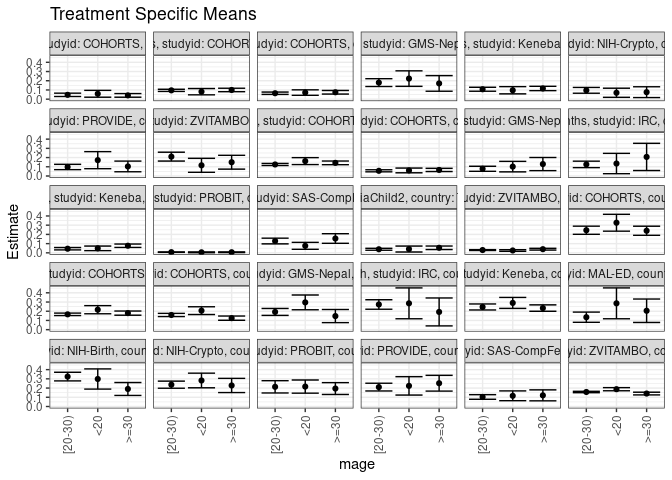

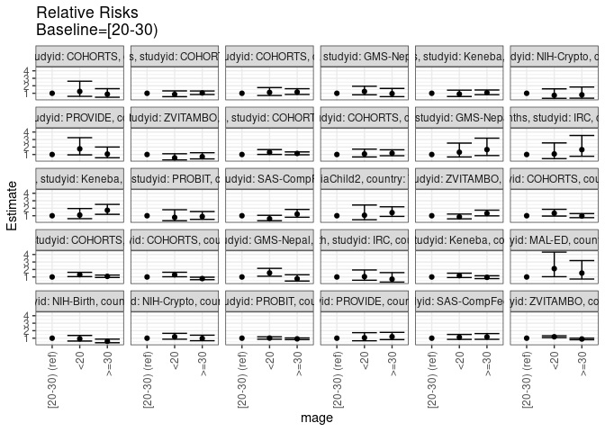

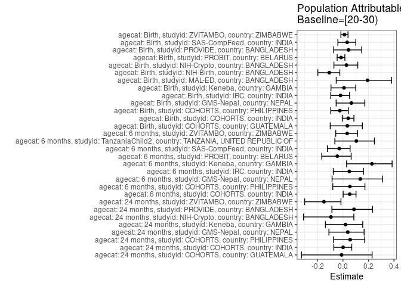

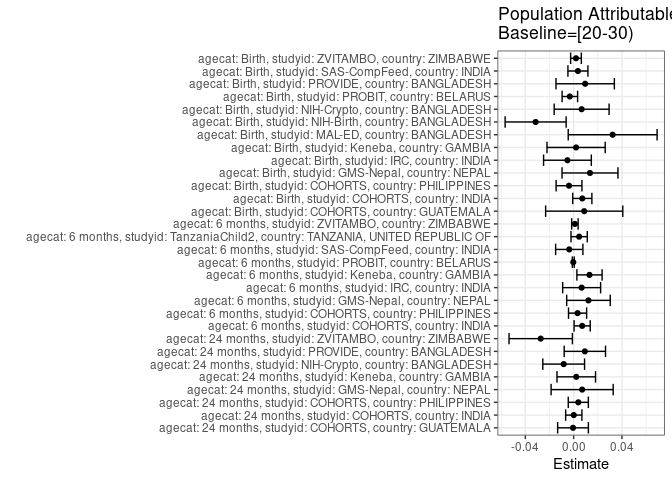

## Results Table

### Parameter: TSM

| agecat | studyid | country | intervention_level | baseline_level | estimate | ci_lower | ci_upper |
| --- | --- | --- | --- | --- | --- | --- | --- |
| Birth | COHORTS | GUATEMALA | [20-30) | NA | 0.2452316 | 0.2011865 | 0.2892767 |
| Birth | COHORTS | GUATEMALA | <20 | NA | 0.3267327 | 0.2352024 | 0.4182630 |
| Birth | COHORTS | GUATEMALA | >=30 | NA | 0.2395833 | 0.1902553 | 0.2889113 |
| Birth | COHORTS | INDIA | [20-30) | NA | 0.1662732 | 0.1528700 | 0.1796764 |
| Birth | COHORTS | INDIA | <20 | NA | 0.2166172 | 0.1726311 | 0.2606034 |
| Birth | COHORTS | INDIA | >=30 | NA | 0.1795104 | 0.1568592 | 0.2021616 |
| Birth | COHORTS | PHILIPPINES | [20-30) | NA | 0.1594037 | 0.1422209 | 0.1765864 |
| Birth | COHORTS | PHILIPPINES | <20 | NA | 0.2062147 | 0.1640613 | 0.2483681 |
| Birth | COHORTS | PHILIPPINES | >=30 | NA | 0.1248439 | 0.1019493 | 0.1477386 |
| Birth | GMS-Nepal | NEPAL | [20-30) | NA | 0.1923990 | 0.1547160 | 0.2300821 |
| Birth | GMS-Nepal | NEPAL | <20 | NA | 0.2960000 | 0.2159126 | 0.3760874 |
| Birth | GMS-Nepal | NEPAL | >=30 | NA | 0.1473684 | 0.0760325 | 0.2187043 |
| Birth | IRC | INDIA | [20-30) | NA | 0.2733564 | 0.2218977 | 0.3248151 |
| Birth | IRC | INDIA | <20 | NA | 0.2857143 | 0.1181409 | 0.4532877 |
| Birth | IRC | INDIA | >=30 | NA | 0.1923077 | 0.0405968 | 0.3440186 |
| Birth | Keneba | GAMBIA | [20-30) | NA | 0.2462687 | 0.2136346 | 0.2789028 |
| Birth | Keneba | GAMBIA | <20 | NA | 0.2901786 | 0.2307248 | 0.3496324 |
| Birth | Keneba | GAMBIA | >=30 | NA | 0.2342657 | 0.1995448 | 0.2689867 |
| Birth | MAL-ED | BANGLADESH | [20-30) | NA | 0.1351351 | 0.0799289 | 0.1903413 |
| Birth | MAL-ED | BANGLADESH | <20 | NA | 0.2857143 | 0.1179949 | 0.4534337 |
| Birth | MAL-ED | BANGLADESH | >=30 | NA | 0.2051282 | 0.0781032 | 0.3321533 |
| Birth | NIH-Birth | BANGLADESH | [20-30) | NA | 0.3246753 | 0.2778611 | 0.3714896 |
| Birth | NIH-Birth | BANGLADESH | <20 | NA | 0.2985075 | 0.1888397 | 0.4081753 |
| Birth | NIH-Birth | BANGLADESH | >=30 | NA | 0.1900826 | 0.1201103 | 0.2600550 |
| Birth | NIH-Crypto | BANGLADESH | [20-30) | NA | 0.2366738 | 0.1981792 | 0.2751683 |
| Birth | NIH-Crypto | BANGLADESH | <20 | NA | 0.2822581 | 0.2029802 | 0.3615359 |
| Birth | NIH-Crypto | BANGLADESH | >=30 | NA | 0.2280702 | 0.1509929 | 0.3051474 |
| Birth | PROBIT | BELARUS | [20-30) | NA | 0.2134695 | 0.1469896 | 0.2799495 |
| Birth | PROBIT | BELARUS | <20 | NA | 0.2161198 | 0.1447086 | 0.2875311 |
| Birth | PROBIT | BELARUS | >=30 | NA | 0.1947743 | 0.1304540 | 0.2590947 |

[output cut: 60 more lines]

### Parameter: E(Y)

| agecat | studyid | country | intervention_level | baseline_level | estimate | ci_lower | ci_upper |
| --- | --- | --- | --- | --- | --- | --- | --- |
| Birth | COHORTS | GUATEMALA | NA | NA | 0.2539683 | 0.2229196 | 0.2850169 |
| Birth | COHORTS | INDIA | NA | NA | 0.1734393 | 0.1622569 | 0.1846217 |
| Birth | COHORTS | PHILIPPINES | NA | NA | 0.1555709 | 0.1423748 | 0.1687670 |
| Birth | GMS-Nepal | NEPAL | NA | NA | 0.2059282 | 0.1745993 | 0.2372572 |
| Birth | IRC | INDIA | NA | NA | 0.2682216 | 0.2212677 | 0.3151755 |
| Birth | Keneba | GAMBIA | NA | NA | 0.2482947 | 0.2261720 | 0.2704173 |
| Birth | MAL-ED | BANGLADESH | NA | NA | 0.1674419 | 0.1174176 | 0.2174661 |
| Birth | NIH-Birth | BANGLADESH | NA | NA | 0.2931937 | 0.2558878 | 0.3304996 |
| Birth | NIH-Crypto | BANGLADESH | NA | NA | 0.2432815 | 0.2116319 | 0.2749310 |
| Birth | PROBIT | BELARUS | NA | NA | 0.2103206 | 0.1450833 | 0.2755580 |
| Birth | PROVIDE | BANGLADESH | NA | NA | 0.2199248 | 0.1846953 | 0.2551543 |
| Birth | SAS-CompFeed | INDIA | NA | NA | 0.1069810 | 0.0760961 | 0.1378659 |
| Birth | ZVITAMBO | ZIMBABWE | NA | NA | 0.1593044 | 0.1529843 | 0.1656245 |
| 6 months | COHORTS | INDIA | NA | NA | 0.1321217 | 0.1226366 | 0.1416069 |
| 6 months | COHORTS | PHILIPPINES | NA | NA | 0.0594974 | 0.0505830 | 0.0684118 |
| 6 months | GMS-Nepal | NEPAL | NA | NA | 0.0904255 | 0.0667359 | 0.1141152 |
| 6 months | IRC | INDIA | NA | NA | 0.1323529 | 0.0994307 | 0.1652752 |
| 6 months | Keneba | GAMBIA | NA | NA | 0.0576923 | 0.0476698 | 0.0677148 |
| 6 months | PROBIT | BELARUS | NA | NA | 0.0068541 | 0.0051915 | 0.0085167 |
| 6 months | SAS-CompFeed | INDIA | NA | NA | 0.1244378 | 0.0992652 | 0.1496104 |
| 6 months | TanzaniaChild2 | TANZANIA, UNITED REPUBLIC OF | NA | NA | 0.0432621 | 0.0343680 | 0.0521561 |
| 6 months | ZVITAMBO | ZIMBABWE | NA | NA | 0.0312169 | 0.0275173 | 0.0349165 |
| 24 months | COHORTS | GUATEMALA | NA | NA | 0.0464684 | 0.0338852 | 0.0590516 |
| 24 months | COHORTS | INDIA | NA | NA | 0.0957708 | 0.0862423 | 0.1052993 |
| 24 months | COHORTS | PHILIPPINES | NA | NA | 0.0681911 | 0.0582056 | 0.0781766 |
| 24 months | GMS-Nepal | NEPAL | NA | NA | 0.1868583 | 0.1522030 | 0.2215136 |
| 24 months | Keneba | GAMBIA | NA | NA | 0.1096210 | 0.0948307 | 0.1244113 |
| 24 months | NIH-Crypto | BANGLADESH | NA | NA | 0.0875486 | 0.0630907 | 0.1120065 |
| 24 months | PROVIDE | BANGLADESH | NA | NA | 0.1070812 | 0.0818727 | 0.1322897 |
| 24 months | ZVITAMBO | ZIMBABWE | NA | NA | 0.1828704 | 0.1463759 | 0.2193648 |

### Parameter: RR

| agecat | studyid | country | intervention_level | baseline_level | estimate | ci_lower | ci_upper |
| --- | --- | --- | --- | --- | --- | --- | --- |
| Birth | COHORTS | GUATEMALA | [20-30) | [20-30) | 1.0000000 | 1.0000000 | 1.0000000 |
| Birth | COHORTS | GUATEMALA | <20 | [20-30) | 1.3323432 | 0.9552038 | 1.8583873 |
| Birth | COHORTS | GUATEMALA | >=30 | [20-30) | 0.9769676 | 0.7433992 | 1.2839208 |
| Birth | COHORTS | INDIA | [20-30) | [20-30) | 1.0000000 | 1.0000000 | 1.0000000 |
| Birth | COHORTS | INDIA | <20 | [20-30) | 1.3027790 | 1.0471011 | 1.6208875 |
| Birth | COHORTS | INDIA | >=30 | [20-30) | 1.0796114 | 0.9294780 | 1.2539950 |
| Birth | COHORTS | PHILIPPINES | [20-30) | [20-30) | 1.0000000 | 1.0000000 | 1.0000000 |
| Birth | COHORTS | PHILIPPINES | <20 | [20-30) | 1.2936634 | 1.0267337 | 1.6299893 |
| Birth | COHORTS | PHILIPPINES | >=30 | [20-30) | 0.7831937 | 0.6331199 | 0.9688407 |
| Birth | GMS-Nepal | NEPAL | [20-30) | [20-30) | 1.0000000 | 1.0000000 | 1.0000000 |
| Birth | GMS-Nepal | NEPAL | <20 | [20-30) | 1.5384691 | 1.1016095 | 2.1485720 |
| Birth | GMS-Nepal | NEPAL | >=30 | [20-30) | 0.7659519 | 0.4543791 | 1.2911736 |
| Birth | IRC | INDIA | [20-30) | [20-30) | 1.0000000 | 1.0000000 | 1.0000000 |
| Birth | IRC | INDIA | <20 | [20-30) | 1.0452080 | 0.5645305 | 1.9351651 |
| Birth | IRC | INDIA | >=30 | [20-30) | 0.7035054 | 0.3126330 | 1.5830697 |
| Birth | Keneba | GAMBIA | [20-30) | [20-30) | 1.0000000 | 1.0000000 | 1.0000000 |
| Birth | Keneba | GAMBIA | <20 | [20-30) | 1.1783009 | 0.9231791 | 1.5039258 |
| Birth | Keneba | GAMBIA | >=30 | [20-30) | 0.9512609 | 0.7797512 | 1.1604948 |
| Birth | MAL-ED | BANGLADESH | [20-30) | [20-30) | 1.0000000 | 1.0000000 | 1.0000000 |
| Birth | MAL-ED | BANGLADESH | <20 | [20-30) | 2.1142857 | 1.0341049 | 4.3227760 |
| Birth | MAL-ED | BANGLADESH | >=30 | [20-30) | 1.5179487 | 0.7228866 | 3.1874546 |
| Birth | NIH-Birth | BANGLADESH | [20-30) | [20-30) | 1.0000000 | 1.0000000 | 1.0000000 |
| Birth | NIH-Birth | BANGLADESH | <20 | [20-30) | 0.9194030 | 0.6195886 | 1.3642953 |
| Birth | NIH-Birth | BANGLADESH | >=30 | [20-30) | 0.5854545 | 0.3942723 | 0.8693408 |
| Birth | NIH-Crypto | BANGLADESH | [20-30) | [20-30) | 1.0000000 | 1.0000000 | 1.0000000 |
| Birth | NIH-Crypto | BANGLADESH | <20 | [20-30) | 1.1926039 | 0.8620638 | 1.6498825 |
| Birth | NIH-Crypto | BANGLADESH | >=30 | [20-30) | 0.9636479 | 0.6622674 | 1.4021786 |
| Birth | PROBIT | BELARUS | [20-30) | [20-30) | 1.0000000 | 1.0000000 | 1.0000000 |
| Birth | PROBIT | BELARUS | <20 | [20-30) | 1.0124154 | 0.8664691 | 1.1829447 |
| Birth | PROBIT | BELARUS | >=30 | [20-30) | 0.9124223 | 0.8068033 | 1.0318679 |

[output cut: 60 more lines]

### Parameter: PAR

| agecat | studyid | country | intervention_level | baseline_level | estimate | ci_lower | ci_upper |
| --- | --- | --- | --- | --- | --- | --- | --- |
| Birth | COHORTS | GUATEMALA | [20-30) | NA | 0.0087366 | -0.0232082 | 0.0406815 |
| Birth | COHORTS | INDIA | [20-30) | NA | 0.0071661 | -0.0007619 | 0.0150941 |
| Birth | COHORTS | PHILIPPINES | [20-30) | NA | -0.0038328 | -0.0145169 | 0.0068513 |
| Birth | GMS-Nepal | NEPAL | [20-30) | NA | 0.0135292 | -0.0096274 | 0.0366858 |
| Birth | IRC | INDIA | [20-30) | NA | -0.0051348 | -0.0248945 | 0.0146249 |
| Birth | Keneba | GAMBIA | [20-30) | NA | 0.0020260 | -0.0220768 | 0.0261288 |
| Birth | MAL-ED | BANGLADESH | [20-30) | NA | 0.0323067 | -0.0044929 | 0.0691063 |
| Birth | NIH-Birth | BANGLADESH | [20-30) | NA | -0.0314816 | -0.0567454 | -0.0062178 |
| Birth | NIH-Crypto | BANGLADESH | [20-30) | NA | 0.0066077 | -0.0161416 | 0.0293570 |
| Birth | PROBIT | BELARUS | [20-30) | NA | -0.0031489 | -0.0095672 | 0.0032695 |
| Birth | PROVIDE | BANGLADESH | [20-30) | NA | 0.0095423 | -0.0146321 | 0.0337167 |
| Birth | SAS-CompFeed | INDIA | [20-30) | NA | 0.0035327 | -0.0047505 | 0.0118159 |
| Birth | ZVITAMBO | ZIMBABWE | [20-30) | NA | 0.0019311 | -0.0024887 | 0.0063510 |
| 6 months | COHORTS | INDIA | [20-30) | NA | 0.0070465 | 0.0003635 | 0.0137295 |
| 6 months | COHORTS | PHILIPPINES | [20-30) | NA | 0.0032474 | -0.0042486 | 0.0107435 |
| 6 months | GMS-Nepal | NEPAL | [20-30) | NA | 0.0122584 | -0.0057779 | 0.0302947 |
| 6 months | IRC | INDIA | [20-30) | NA | 0.0066219 | -0.0090812 | 0.0223251 |
| 6 months | Keneba | GAMBIA | [20-30) | NA | 0.0131128 | 0.0026771 | 0.0235484 |
| 6 months | PROBIT | BELARUS | [20-30) | NA | -0.0003052 | -0.0010941 | 0.0004838 |
| 6 months | SAS-CompFeed | INDIA | [20-30) | NA | -0.0036410 | -0.0149381 | 0.0076560 |
| 6 months | TanzaniaChild2 | TANZANIA, UNITED REPUBLIC OF | [20-30) | NA | 0.0045377 | -0.0022040 | 0.0112794 |
| 6 months | ZVITAMBO | ZIMBABWE | [20-30) | NA | 0.0010268 | -0.0016493 | 0.0037030 |
| 24 months | COHORTS | GUATEMALA | [20-30) | NA | -0.0005241 | -0.0132499 | 0.0122017 |
| 24 months | COHORTS | INDIA | [20-30) | NA | 0.0001044 | -0.0066256 | 0.0068344 |
| 24 months | COHORTS | PHILIPPINES | [20-30) | NA | 0.0038516 | -0.0044626 | 0.0121658 |
| 24 months | GMS-Nepal | NEPAL | [20-30) | NA | 0.0070476 | -0.0186511 | 0.0327463 |
| 24 months | Keneba | GAMBIA | [20-30) | NA | 0.0021621 | -0.0138034 | 0.0181276 |
| 24 months | NIH-Crypto | BANGLADESH | [20-30) | NA | -0.0082597 | -0.0255539 | 0.0090344 |
| 24 months | PROVIDE | BANGLADESH | [20-30) | NA | 0.0092817 | -0.0078295 | 0.0263928 |
| 24 months | ZVITAMBO | ZIMBABWE | [20-30) | NA | -0.0272746 | -0.0535163 | -0.0010329 |

### Parameter: PAF

| agecat | studyid | country | intervention_level | baseline_level | estimate | ci_lower | ci_upper |
| --- | --- | --- | --- | --- | --- | --- | --- |
| Birth | COHORTS | GUATEMALA | [20-30) | NA | 0.0344005 | -0.0999150 | 0.1523142 |
| Birth | COHORTS | INDIA | [20-30) | NA | 0.0413176 | -0.0054517 | 0.0859113 |
| Birth | COHORTS | PHILIPPINES | [20-30) | NA | -0.0246369 | -0.0956463 | 0.0417703 |
| Birth | GMS-Nepal | NEPAL | [20-30) | NA | 0.0656986 | -0.0535396 | 0.1714415 |
| Birth | IRC | INDIA | [20-30) | NA | -0.0191440 | -0.0955205 | 0.0519078 |
| Birth | Keneba | GAMBIA | [20-30) | NA | 0.0081598 | -0.0938217 | 0.1006331 |
| Birth | MAL-ED | BANGLADESH | [20-30) | NA | 0.1929429 | -0.0529073 | 0.3813880 |
| Birth | NIH-Birth | BANGLADESH | [20-30) | NA | -0.1073748 | -0.1968882 | -0.0245559 |
| Birth | NIH-Crypto | BANGLADESH | [20-30) | NA | 0.0271607 | -0.0709637 | 0.1162947 |
| Birth | PROBIT | BELARUS | [20-30) | NA | -0.0149719 | -0.0456147 | 0.0147730 |
| Birth | PROVIDE | BANGLADESH | [20-30) | NA | 0.0433889 | -0.0729830 | 0.1471395 |
| Birth | SAS-CompFeed | INDIA | [20-30) | NA | 0.0330216 | -0.0398740 | 0.1008072 |
| Birth | ZVITAMBO | ZIMBABWE | [20-30) | NA | 0.0121223 | -0.0160131 | 0.0394785 |
| 6 months | COHORTS | INDIA | [20-30) | NA | 0.0533337 | 0.0014848 | 0.1024903 |
| 6 months | COHORTS | PHILIPPINES | [20-30) | NA | 0.0545807 | -0.0799220 | 0.1723314 |
| 6 months | GMS-Nepal | NEPAL | [20-30) | NA | 0.1355637 | -0.0854708 | 0.3115889 |
| 6 months | IRC | INDIA | [20-30) | NA | 0.0500325 | -0.0758153 | 0.1611587 |
| 6 months | Keneba | GAMBIA | [20-30) | NA | 0.2272881 | 0.0284512 | 0.3854310 |
| 6 months | PROBIT | BELARUS | [20-30) | NA | -0.0445245 | -0.1661452 | 0.0644120 |
| 6 months | SAS-CompFeed | INDIA | [20-30) | NA | -0.0292599 | -0.1221406 | 0.0559330 |
| 6 months | TanzaniaChild2 | TANZANIA, UNITED REPUBLIC OF | [20-30) | NA | 0.1048883 | -0.0636953 | 0.2467534 |
| 6 months | ZVITAMBO | ZIMBABWE | [20-30) | NA | 0.0328941 | -0.0566559 | 0.1148548 |
| 24 months | COHORTS | GUATEMALA | [20-30) | NA | -0.0112782 | -0.3257854 | 0.2286206 |
| 24 months | COHORTS | INDIA | [20-30) | NA | 0.0010902 | -0.0717120 | 0.0689469 |
| 24 months | COHORTS | PHILIPPINES | [20-30) | NA | 0.0564825 | -0.0733959 | 0.1706459 |
| 24 months | GMS-Nepal | NEPAL | [20-30) | NA | 0.0377162 | -0.1100131 | 0.1657845 |
| 24 months | Keneba | GAMBIA | [20-30) | NA | 0.0197232 | -0.1372735 | 0.1550471 |
| 24 months | NIH-Crypto | BANGLADESH | [20-30) | NA | -0.0943446 | -0.3091652 | 0.0852260 |
| 24 months | PROVIDE | BANGLADESH | [20-30) | NA | 0.0866788 | -0.0867337 | 0.2324194 |
| 24 months | ZVITAMBO | ZIMBABWE | [20-30) | NA | -0.1491469 | -0.3002840 | -0.0155771 |